```python
import matplotlib.pyplot as plt
import numpy as np
import pandas as pd
import seaborn as sns

pd.set_option("display.max_columns", 85)
```

# Voting Classifier

A voting classifier aggregates the predictions from an ensemble of models and predict the class with the most votes (hard voting) or highest average probability (soft voting).

> Somewhat surprisingly, this voting classifier often achieves a higher accuracy than the best classifier in the ensemble. *Gèron, Ch 7*

A voting classifier performs best when the member classifiers make independent predictions.

> Ensemble methods work best when the predictors are as independent from one another as possible. One way to get diverse classifiers is to train them using very different algorithms. This increases the chance that they will make very different types of errors, improving the ensemble’s accuracy. *Gèron, Ch 7*

[figure not shown]

```python
df = pd.read_csv("../data/abnormal_writeout_noscale.data.csv")

# trascurare da ACC a UVM
start_drop = df.columns.get_loc("ACC")
end_drop = df.columns.get_loc("UVM")
cols = np.arange(start_drop, end_drop + 1)
df.drop(df.columns[cols], axis=1, inplace=True)

# trascurare alcune colonne
df.drop("TTT_freq", axis=1, inplace=True)
df.drop("oldest_phylostratum_factor", axis=1, inplace=True)
df.drop("Unnamed: 0", axis=1, inplace=True)

# Drop NaNs
df.dropna(inplace=True)

# Sort features
resp = df["response"].to_numpy()
occ = df["occ_total_sum"]
age = df["oldest_phylostratum"].to_numpy()
conf = df.drop(labels=["response", "occ_total_sum", "oldest_phylostratum"], axis=1).to_numpy()

X = np.c_[occ, age, conf]
Y = resp

from sklearn.model_selection import train_test_split

X_train, X_test, y_train, y_test = train_test_split(X, Y, test_size=0.2, random_state=42)
print("Feature matrix shape:", X_train.shape, X_test.shape)
```

```
Feature matrix shape: (14536, 83) (3634, 83)
```

```python
from sklearn.base import BaseEstimator, TransformerMixin
from sklearn.decomposition import PCA

conf_cols = np.arange(2, X.shape[1])  # Columns of confounder variables (highly colinear)


class ConfounderPCA(BaseEstimator, TransformerMixin):
    """ Custom PCA transformer for this dataset"""

    def __init__(self, explained_variance=0.95, apply_PCA=True):
        self.apply_PCA = apply_PCA
        self.explained_variance = explained_variance
        if self.apply_PCA:
            self.pca = PCA(n_components=self.explained_variance)

    def fit(self, X, y=None):
        if self.apply_PCA:
            self.pca.fit(X[:, conf_cols])
        return self

    def transform(self, X, y=None):
        if self.apply_PCA:
            X_conf_pca = self.pca.transform(X[:, conf_cols])
            return np.c_[X[:, :2], X_conf_pca]
        else:
            return X
```

```python
from sklearn.metrics import auc, make_scorer, precision_recall_curve


def auprc(y_true, y_scores, **kwargs):
    """ Remember to use make_scorer(auprc, needs_proba=True,) """
    precisions, recalls, thresholds = precision_recall_curve(y_true, y_scores)
    # result is sum of the areas under each curve
    return auc(thresholds, precisions[:-1]) + auc(thresholds, recalls[:-1])
```

# [Spearman Correlation Coefficient](https://docs.scipy.org/doc/scipy/reference/generated/scipy.stats.spearmanr.html)

The *spearman correlation coefficient* is defined as the pearson correlation coefficient between the rank variables:

$$ r_s = \rho_{R(X), R(Y)} = \frac{Cov(R(X), R(Y))}{\sigma_R(X), \sigma_R(Y)}. $$

If all $n$ ranks are distinct, it can be computed using

$$ r_s = 1 - \frac{6 \sum d_i^2 }{n(n^2-1)} \\ \\ d_i = R(X_i) - R(Y_i). $$

```python
from imblearn.ensemble import BalancedRandomForestClassifier
from sklearn.linear_model import LogisticRegression
from sklearn.naive_bayes import GaussianNB
from sklearn.pipeline import Pipeline
from sklearn.preprocessing import StandardScaler
from sklearn.svm import SVC

rf_clf = Pipeline([
    ('scaler', StandardScaler()), # !! Absolutely necessary before PCA
    ("pca", ConfounderPCA()),
    ("rf", BalancedRandomForestClassifier(
        max_depth=10,
        max_features=2,
        min_samples_leaf=2,
        min_samples_split=20,
        n_estimators=500,
        random_state=42, n_jobs=-1
    ))
])

lr_clf = Pipeline([
    ('scaler', StandardScaler()), # Improves convergence
    # ("pca", ConfounderPCA()),
    ("lr", LogisticRegression(max_iter=500, class_weight='balanced')),
])

gnb_clf = Pipeline([
    # ('scaler', StandardScaler()),
    # ("pca", ConfounderPCA()),
    ("gnb", GaussianNB()),
])

svm_clf = Pipeline([
    ("scaler", StandardScaler()),
    # ("pca", ConfounderPCA()),
    ("svc", SVC(
        C=1.0, shrinking=False,
        class_weight='balanced',
        kernel="rbf",
        probability=True,
        random_state=0,
    ))
])
```

```python
rf_clf.fit(X_train, y_train)
lr_clf.fit(X_train, y_train)
gnb_clf.fit(X_train, y_train)
svm_clf.fit(X_train, y_train)
```

```
Pipeline(steps=[('scaler', StandardScaler()),
                ('svc',
                 SVC(class_weight='balanced', probability=True, random_state=0,
                     shrinking=False))])
```

```python
pred_df = pd.DataFrame()

pred_df["LR_pred"] = lr_clf.predict(X_test)
pred_df["RF_pred"] = rf_clf.predict(X_test)
pred_df["GNB_pred"] = gnb_clf.predict(X_test)
pred_df["SVM_pred"] = svm_clf.predict(X_test)

proba_df = pd.DataFrame()

proba_df["LR_proba"] = lr_clf.predict_proba(X_test)[:, 0]
proba_df["RF_proba"] = rf_clf.predict_proba(X_test)[:, 0]
proba_df["GNB_proba"] = gnb_clf.predict_proba(X_test)[:, 0]
proba_df["SVM_proba"] = svm_clf.predict_proba(X_test)[:, 0]
```

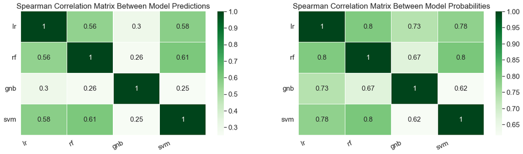

```python
from scipy.stats import spearmanr

# Build the plot
fig, ax = plt.subplots(1, 2, figsize=(20, 5))
sns.set(font_scale=1.4)

# Add labels to the plot
model_names = ["lr", "rf", "gnb", "svm"]
tick_marks = np.arange(len(model_names)) + 0.1
tick_marks2 = tick_marks + 0.4

# Plot 1
sns.heatmap(spearmanr(pred_df).correlation, annot=True, annot_kws={"size": 15}, cmap=plt.cm.Greens, linewidths=0.2, ax=ax[0])
ax[0].set_xticks(tick_marks)
ax[0].set_xticklabels(model_names)
ax[0].tick_params(axis="x", labelrotation=25)
ax[0].set_yticks(tick_marks2)
ax[0].set_yticklabels(model_names)
ax[0].tick_params(axis="y", labelrotation=0)
ax[0].title.set_text("Spearman Correlation Matrix Between Model Predictions")

# Plot 2
sns.heatmap(spearmanr(proba_df).correlation, annot=True, annot_kws={"size": 15}, cmap=plt.cm.Greens, linewidths=0.2, ax=ax[1])
ax[1].set_xticks(tick_marks)
ax[1].set_xticklabels(model_names)
ax[1].tick_params(axis="x", labelrotation=25)
ax[1].set_yticks(tick_marks2)
ax[1].set_yticklabels(model_names)
ax[1].tick_params(axis="y", labelrotation=0)
ax[1].title.set_text("Spearman Correlation Matrix Between Model Probabilities")

plt.show()
```

**Figure: Spearman Correlation Matrices for member model predictions and probabilities.** Because model predictions can diverge to 0 and 1 despite similar probabilities, the correlations between predictions are always lower than the correlations between probabilities. By the figure on the left, it would seem that the gaussian naive bayes classifier is the most independent from the other classifiers.

# Feature Importance

If each of the member models makes predictions using different features, that would be a good indicator that the voting method should perform better

[Logistic Regression](https://scikit-learn.org/stable/modules/generated/sklearn.linear_model.LogisticRegression.html)  
[Random Forest Feature Importance](https://scikit-learn.org/stable/modules/generated/sklearn.ensemble.RandomForestClassifier.html#sklearn.ensemble.RandomForestClassifier.feature_importances_)

```python
lr_clf = Pipeline([
    ('scaler', StandardScaler()),
    ("lr", LogisticRegression(max_iter=500, class_weight='balanced')),
])

lr_clf.fit(X_train, y_train)
```

```python
importance_df = pd.DataFrame(np.reshape(lr_clf["lr"].coef_, (lr_clf["lr"].coef_.shape[1], 1)), columns=["Score"])
top_features_lr = importance_df.sort_values(by="Score", key=abs, ascending=False).index.to_numpy()
importance_df.sort_values(by="Score", key=abs, ascending=False).head(10)
```

|  | Score |
| --- | --- |
| 79 | -1.029191 |
| 66 | 0.896040 |
| 3 | 0.855108 |
| 45 | -0.771229 |
| 77 | -0.750641 |
| 71 | 0.731362 |
| 46 | -0.698490 |
| 50 | 0.696801 |
| 31 | -0.684703 |
| 58 | 0.684126 |

```python
rf_clf = Pipeline([
    ('scaler', StandardScaler()), # !! Absolutely necessary before PCA
    ("pca", ConfounderPCA()),
    ("rf", BalancedRandomForestClassifier(
        max_depth=10,
        max_features=2,
        min_samples_leaf=2,
        min_samples_split=20,
        n_estimators=500,
        random_state=42, n_jobs=-1
    ))
])

rf_clf.fit(X_train, y_train)
```

```python
importance_df = pd.DataFrame(rf_clf["rf"].feature_importances_, columns=["Score"])
top_features_rf = importance_df.sort_values(by="Score", key=abs, ascending=False).index.to_numpy()
importance_df.sort_values(by="Score", key=abs, ascending=False).head(10)
```

|  | Score |
| --- | --- |
| 0 | 0.058677 |
| 1 | 0.044785 |
| 8 | 0.029464 |
| 3 | 0.028224 |
| 10 | 0.026352 |
| 25 | 0.025785 |
| 13 | 0.025348 |
| 20 | 0.024915 |
| 23 | 0.023124 |
| 17 | 0.022813 |

### [Permutation Feature Importance](https://scikit-learn.org/stable/modules/permutation_importance.html#permutation-importance)

> The permutation feature importance is defined to be the decrease in a model score when a single feature value is randomly shuffled. This procedure breaks the relationship between the feature and the target, thus the drop in the model score is indicative of how much the model depends on the feature. *Scikit-Learn 4.2*

> **Warning:** Features that are deemed of low importance for a bad model (low cross-validation score) could be very important for a good model. Therefore it is always important to evaluate the predictive power of a model using a held-out set (or better with cross-validation) prior to computing importances. Permutation importance **does not** reflect to the **intrinsic predictive value** of a feature by itself but how **important** this feature is **for a particular model**.

```python
from sklearn.inspection import permutation_importance
```

```python
gnb_clf = Pipeline([
    # ('scaler', StandardScaler()),
    # ("pca", ConfounderPCA()),
    ("gnb", GaussianNB()),
])

gnb_clf.fit(X_train, y_train)
```

```python
importance_gnb = permutation_importance(gnb_clf, X_train, y_train, n_repeats=10, random_state=0, scoring='roc_auc')
```

```python
importance_df = pd.DataFrame(importance_gnb.importances_mean, columns=["Score"])
top_features_gnb = importance_df.sort_values(by="Score", key=abs, ascending=False).index.to_numpy()
importance_df.sort_values(by="Score", key=abs, ascending=False).head(10)
```

|  | Score |
| --- | --- |
| 1 | 0.036090 |
| 0 | 0.019175 |
| 2 | 0.012107 |
| 18 | 0.007616 |
| 16 | 0.007154 |
| 9 | 0.001076 |
| 8 | -0.001074 |
| 6 | 0.001055 |
| 15 | 0.001017 |
| 10 | 0.000886 |

```python
svm_clf = Pipeline([
    ("scaler", StandardScaler()),
    # ("pca", ConfounderPCA()),
    ("svc", SVC(
        C=1.0, shrinking=False,
        class_weight='balanced',
        kernel="rbf",
        probability=True,
        random_state=0,
    ))
])

svm_clf.fit(X_train, y_train)
```

```python
# TODO
importance_svm = permutation_importance(svm_clf, X_train, y_train, n_repeats=10, random_state=0, scoring='roc_auc', n_jobs=-1)
```

```python
importance_df = pd.DataFrame(importance_svm.importances_mean, columns=["Score"])
top_features_svm = importance_df.sort_values(by="Score", key=abs, ascending=False).index.to_numpy()
importance_df.sort_values(by="Score", key=abs, ascending=False).head(10)
```

[output not shown]

```python
n = 20
print("LR highest scoring features: ", top_features_lr[:n])
print("RF highest scoring features: ", top_features_rf[:n]) # Uses PCA
print("GNB highest scoring features:", top_features_gnb[:n])
```

```
LR highest scoring features:  [79 66  3 45 77 71 46 50 31 58 32 28 40 30 29 56 80 78 82 22]
RF highest scoring features:  [ 0  1  8  3 10 25 13 20 23 17  4 30 19  5  7 46 36 41 18 24]
GNB highest scoring features: [ 1  0  2 18 16  9  8  6 15 10 14  5 11 19  3  4 12  7 17 34]
```

# [Voting Classifier](https://scikit-learn.org/stable/modules/generated/sklearn.ensemble.VotingClassifier.html#sklearn.ensemble.VotingClassifier)

How did I determine the steps in each model's pipeline?

- Random Forest: scaling is necessary for PCA, PCA improves random forest generalizatin (cit. Gèron)
- Logistic Regression: scaling improves model convergence
- Gaussian Naive Bayes: does not seem to need either scaling or PCA
- Support Vector Machine: SVM's are sensitive to feature scales

```python
from sklearn.ensemble import VotingClassifier
from sklearn.model_selection import cross_validate

rf_clf = Pipeline([
    ('scaler', StandardScaler()), # !! Absolutely necessary before PCA
    ("pca", ConfounderPCA()),
    ("rf", BalancedRandomForestClassifier(
        max_depth=10,
        max_features=2,
        min_samples_leaf=2,
        min_samples_split=20,
        n_estimators=500,
        random_state=42, n_jobs=-1
    ))
])

lr_clf = Pipeline([
    ('scaler', StandardScaler()), # Improves convergence
    # ("pca", ConfounderPCA()),
    ("lr", LogisticRegression(max_iter=500, class_weight='balanced')),
])

gnb_clf = Pipeline([
    # ('scaler', StandardScaler()),
    # ("pca", ConfounderPCA()),
    ("gnb", GaussianNB()),
])

svm_clf = Pipeline([
    ("scaler", StandardScaler()),
    # ("pca", ConfounderPCA()),
    ("svc", SVC(
        C=1.0, shrinking=False,
        class_weight='balanced',
        kernel="rbf",
        probability=True,
        random_state=0,
    ))
])



# Voting Classifier
models = [("LR", lr_clf),
          ("RF",rf_clf),
          ("GNB", gnb_clf),
          ("SVM", svm_clf)
         ]

sv_clf = VotingClassifier(estimators=models, voting='soft', n_jobs=-1)

# Define metrics
my_metrics = {
    "ROC_AUC": "roc_auc",
    "AUPRC": make_scorer(auprc, needs_proba=True,),  # custom: area under precision-recall-curve
    "Precision": "precision",
    "Recall": "recall",
    "f1-score": "f1",
}

# K-fold cross-validate each model
cv = 10
lr_scores = cross_validate(lr_clf, X_train, y_train, cv=cv, scoring=my_metrics, n_jobs=-1)
rf_scores = cross_validate(rf_clf, X_train, y_train, cv=cv, scoring=my_metrics, n_jobs=-1)
gnb_scores = cross_validate(gnb_clf, X_train, y_train, cv=cv, scoring=my_metrics, n_jobs=-1)
svm_scores = cross_validate(svm_clf, X_train, y_train, cv=cv, scoring=my_metrics, n_jobs=-1)
sv_scores = cross_validate(sv_clf, X_train, y_train, cv=cv, scoring=my_metrics, error_score='raise', n_jobs=-1)
```

[output not shown]

[output cut: 72 more lines]

[output not shown]

```python
lr_df = pd.DataFrame(lr_scores)
rf_df = pd.DataFrame(rf_scores)
gnb_df = pd.DataFrame(gnb_scores)
svm_df = pd.DataFrame(svm_scores)
sv_df = pd.DataFrame(sv_scores)
```

```python
lr_df.to_csv("./results/lr_scores10.csv")
rf_df.to_csv("./results/rf_scores10.csv")
gnb_df.to_csv("./results/gnb_scores10.csv")
svm_df.to_csv("./results/svm_scores10.csv")
sv_df.to_csv("./results/sv_scores10.csv")
```

```python
results_df = pd.DataFrame()
results_df["LogReg (Mean)"] = lr_df.mean()
results_df["LogReg (SEM)"] = lr_df.sem()

results_df["RF (Mean)"] = rf_df.mean()
results_df["RF (SEM)"] = rf_df.sem()

results_df["GNB (Mean)"] = gnb_df.mean()
results_df["GNB (SEM)"] = gnb_df.sem()

results_df["SVM (Mean)"] = svm_df.mean()
results_df["SVM (SEM)"] = svm_df.sem()

results_df["SoftVoting (Mean)"] = sv_df.mean()
results_df["SoftVoting (SEM)"] = sv_df.sem()

results_df.to_csv("./results/cv_results.csv")
results_df
```

[output not shown]

```python
from scipy.stats import ttest_ind

ttest_ind(svm_df.test_ROC_AUC, sv_df.test_ROC_AUC)
```

[output not shown]